# Somativa1-Francine

#### O objetivo é aplicar técnicas de machine learning para analisar dados de desempenho de jogadores, gerando insights que ajudam a otimizar treinos e estratégias. Isso permite criar recomendações personalizadas para melhorar a performance dos atletas.

## **1. Importando Bibliotecas**

```python
import pandas as pd  # Para manipulação de dados
import numpy as np   # Para operações numéricas
import matplotlib.pyplot as plt  # Para visualização de dados
import seaborn as sns  # Visualização de dados, principalmente gráficos de distribuição
from sklearn.model_selection import train_test_split  # Para dividir a base de dados
from sklearn.preprocessing import StandardScaler  # Para normalização dos dados
from sklearn.feature_selection import SelectKBest, f_regression  # Para seleção de atributos
from sklearn.ensemble import RandomForestRegressor  # Algoritmo de aprendizado supervisionado
from sklearn.metrics import mean_squared_error, r2_score # Para avaliar o desempenho do modelo
from sklearn.impute import SimpleImputer  # Para imputação de valores ausentes
from scipy.stats import zscore
```

## **2. Carregando DataSet**

```python
# Carregar o dataset "nba_stats" que contém as estatísticas dos jogadores da NBA
dataset = pd.read_csv("C:/Users/frant/Desktop/ML/nba_stats.csv")
```

## **3. Preparação dos dados**

Nesta etapa fiz uma análise exploratória inicial para compreender melhor o dataset e garantir que as variáveis estejam bem definidas para o modelo preditivo. O objetivo é identificar a estrutura dos dados, tipos de variáveis e verificar possíveis valores extremos (outliers) que possam atrapalhar a performance do modelo.

### **3.1 Análise exploratória**

Primeiro, verifico a quantidade de linhas e colunas, além dos tipos de dados em cada coluna. Em seguida, utilizei o método describe() para obter um resumo estatístico das variáveis numéricas.

```python
# Verificando a quantidade de linhas e colunas
print("Número de linhas:", dataset.shape[0])
print("Número de colunas:", dataset.shape[1])

# Tipos de variáveis
print("\nTipos de variáveis:")
print(dataset.dtypes)

dataset.describe()
```

```
Número de linhas: 24624
Número de colunas: 22

Tipos de variáveis:
Ano                               int64
Posicao                          object
Idade                           float64
Jogos                             int64
TrueShootingPercentage          float64
FreeThrowRate                   float64
OffensiveWinShares              float64
DefensiveWinShares              float64
WinShares                       float64
FieldGoals                        int64
FieldGoalAttempts                 int64
FieldGoalPercentage             float64
TwoPointFieldGoals                int64
TwoPointFieldGoalAttempts         int64
TwoPointFieldGoalPercentage     float64
EffectiveFieldGoalPercentage    float64
FreeThrows                        int64
FreeThrowAttempts                 int64
FreeThrowPercentage             float64
Assists                           int64
PersonalFouls                     int64
Points                            int64
dtype: object
```

|  | Ano | Idade | Jogos | TrueShootingPercentage | FreeThrowRate | OffensiveWinShares | DefensiveWinShares | WinShares | FieldGoals | FieldGoalAttempts | ... | TwoPointFieldGoals | TwoPointFieldGoalAttempts | TwoPointFieldGoalPercentage | EffectiveFieldGoalPercentage | FreeThrows | FreeThrowAttempts | FreeThrowPercentage | Assists | PersonalFouls | Points |
| --- | --- | --- | --- | --- | --- | --- | --- | --- | --- | --- | --- | --- | --- | --- | --- | --- | --- | --- | --- | --- | --- |
| count | 24624.000000 | 24616.000000 | 24624.000000 | 24538.000000 | 24525.000000 | 24585.000000 | 24585.000000 | 24585.000000 | 24624.000000 | 24624.000000 | ... | 24624.000000 | 24624.000000 | 24496.000000 | 24525.000000 | 24624.000000 | 24624.000000 | 23766.000000 | 24624.000000 | 24624.000000 | 24624.000000 |
| mean | 1992.594989 | 26.664405 | 50.837110 | 0.493001 | 0.325455 | 1.257307 | 1.227395 | 2.485796 | 195.325820 | 430.645752 | ... | 178.250447 | 381.756782 | 0.445343 | 0.450658 | 102.389336 | 136.775219 | 0.719279 | 114.852623 | 116.339222 | 510.116350 |
| std | 17.429594 | 3.841892 | 26.496161 | 0.094469 | 0.218971 | 2.136256 | 1.269613 | 3.058638 | 188.114361 | 397.624715 | ... | 179.478923 | 371.260335 | 0.099803 | 0.099200 | 113.373565 | 146.078918 | 0.141824 | 135.863913 | 84.791873 | 492.922981 |
| min | 1950.000000 | 18.000000 | 1.000000 | 0.000000 | 0.000000 | -5.100000 | -1.000000 | -2.800000 | 0.000000 | 0.000000 | ... | 0.000000 | 0.000000 | 0.000000 | 0.000000 | 0.000000 | 0.000000 | 0.000000 | 0.000000 | 0.000000 | 0.000000 |
| 25% | 1981.000000 | 24.000000 | 27.000000 | 0.458000 | 0.208000 | -0.100000 | 0.200000 | 0.200000 | 41.000000 | 99.000000 | ... | 35.000000 | 82.000000 | 0.407000 | 0.414000 | 18.000000 | 27.000000 | 0.657000 | 19.000000 | 39.000000 | 106.000000 |
| 50% | 1996.000000 | 26.000000 | 58.000000 | 0.506000 | 0.296000 | 0.400000 | 0.800000 | 1.400000 | 141.000000 | 321.000000 | ... | 122.000000 | 270.000000 | 0.456000 | 0.463000 | 63.000000 | 88.000000 | 0.743000 | 68.000000 | 109.000000 | 364.000000 |
| 75% | 2007.000000 | 29.000000 | 75.000000 | 0.544000 | 0.400000 | 1.900000 | 1.800000 | 3.800000 | 299.000000 | 661.000000 | ... | 268.000000 | 579.250000 | 0.496000 | 0.501000 | 149.000000 | 201.000000 | 0.808000 | 160.000000 | 182.000000 | 778.000000 |
| max | 2017.000000 | 44.000000 | 88.000000 | 1.136000 | 6.000000 | 18.300000 | 16.000000 | 25.400000 | 1597.000000 | 3159.000000 | ... | 1597.000000 | 3159.000000 | 1.000000 | 1.500000 | 840.000000 | 1363.000000 | 1.000000 | 1164.000000 | 386.000000 | 4029.000000 |

8 rows × 21 columns

**Tipos de variáveis:**

- Variáveis numéricas (inteiras e decimais) e categóricas (como Posicao), que são essenciais para a criação do modelo.

**Principais Variáveis:**

- **TrueShootingPercentage (TS%):** Porcentagem de arremessos verdadeiros, uma métrica de eficiência que leva em conta pontos de arremessos de dois e três pontos e lances livres.
- **OffensiveWinShares:** Contribuição do jogador para as vitórias de sua equipe na temporada, baseada em seu desempenho ofensivo.
- **DefensiveWinShares:** Contribuição do jogador para as vitórias de sua equipe, baseada em seu desempenho defensivo.
- **WinShares:** Total de vitórias que o jogador contribuiu para a equipe, combinando desempenho ofensivo e defensivo.

### **3.2 Detecção de Outliers**

Os gráficos nos mostra a presença de outliers em **FieldGoals** e **FreeThrows**, permitindo ver visualmente onde estão concentrados os valores extremos.

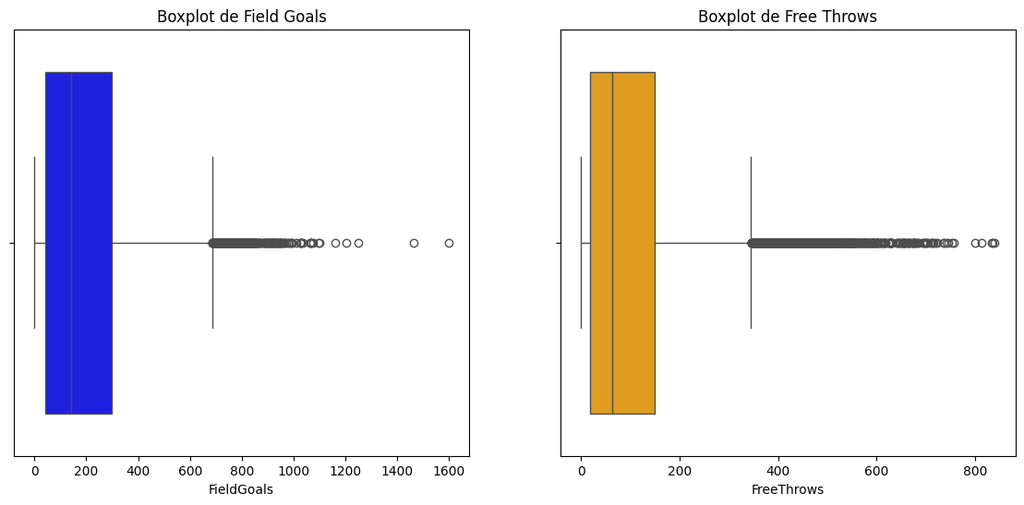

```python
# Boxplot para FieldGoals e FreeThrows
plt.figure(figsize=(14, 6))

# Boxplot para FieldGoals
plt.subplot(1, 2, 1)
sns.boxplot(x=dataset['FieldGoals'], color="blue")  # Usando color em vez de palette
plt.title('Boxplot de Field Goals')

# Boxplot para FreeThrows
plt.subplot(1, 2, 2)
sns.boxplot(x=dataset['FreeThrows'], color="orange")  # Usando color em vez de palette
plt.title('Boxplot de Free Throws')

plt.show()
```

### Análise de correlação com e sem Outliers

Aqui medimos a correlação das variáveis com e sem outliers, ajudando a ver se os valores extremos estão alterando as relações. Se a correlação muda muito sem os outliers, pode indicar que eles distorcem o modelo.

```python
# Definir limite de outliers com base no intervalo interquartil (IQR)
def remove_outliers(df, column):
    Q1 = df[column].quantile(0.25)
    Q3 = df[column].quantile(0.75)
    IQR = Q3 - Q1
    lower_bound = Q1 - 1.5 * IQR
    upper_bound = Q3 + 1.5 * IQR
    return df[(df[column] >= lower_bound) & (df[column] <= upper_bound)]

# Separar dataset com e sem outliers
dataset_no_outliers = remove_outliers(dataset, 'FieldGoals')
dataset_no_outliers = remove_outliers(dataset_no_outliers, 'FreeThrows')

# Comparar correlação entre as variáveis com e sem outliers
print("Correlação com outliers:")
print(dataset[['FieldGoals', 'FreeThrows', 'Points']].corr())

print("\nCorrelação sem outliers:")
print(dataset_no_outliers[['FieldGoals', 'FreeThrows', 'Points']].corr())
```

```
Correlação com outliers:
            FieldGoals  FreeThrows    Points
FieldGoals    1.000000    0.897746  0.993492
FreeThrows    0.897746    1.000000  0.932648
Points        0.993492    0.932648  1.000000

Correlação sem outliers:
            FieldGoals  FreeThrows    Points
FieldGoals    1.000000     0.89059  0.993915
FreeThrows    0.890590     1.00000  0.921030
Points        0.993915     0.92103  1.000000
```

**Análise:** Antes de remover os outliers, as correlações entre as variáveis FieldGoals, FreeThrows e Points eram muito altas, sugerindo uma relação muito forte entre elas. Após remover, as correlações se mantêm altas, mas observamos uma leve diminuição na correlação entre FreeThrows e Points, e entre FieldGoals e FreeThrows. Isso pode indicar que os outliers estavam influenciando essas relações, especialmente a de FreeThrows com Points, onde a correlação diminuiu de 0.932648 para 0.921030.

### Impacto dos Outliers com Scatter Plots

Esses gráficos comparam como a relação entre FieldGoals e Points aparece com e sem outliers, ajudando a visualizar se os outliers criam padrões inesperados ou tendências que podem afetar a previsão de Points.

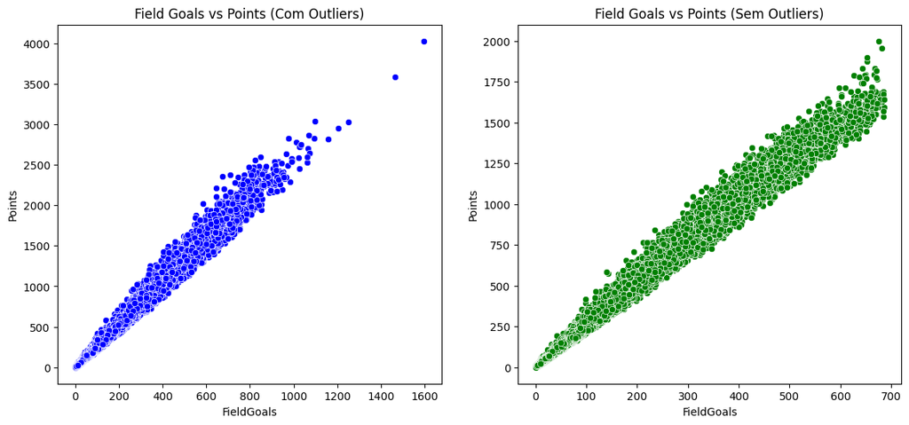

```python
plt.figure(figsize=(14, 6))

# Scatter plot com outliers
plt.subplot(1, 2, 1)
sns.scatterplot(x='FieldGoals', y='Points', data=dataset, color='blue')
plt.title('Field Goals vs Points (Com Outliers)')

# Scatter plot sem outliers
plt.subplot(1, 2, 2)
sns.scatterplot(x='FieldGoals', y='Points', data=dataset_no_outliers, color='green')
plt.title('Field Goals vs Points (Sem Outliers)')

plt.show()
```

### **3.3 Tratamento de Outliers:**

Usei o **z-score** para identificar valores que possam distorcer a análise. Consideramos outliers os valores com desvio acima de 3 em relação à média e revisamos esses valores para ver se precisam ser ajustados ou removidos.

```python
# Calculando os Z-Scores para detectar outliers (valores com z-score maior que 3 são considerados outliers)
z_scores = zscore(dataset.select_dtypes(include=[np.number]))
outliers = (np.abs(z_scores) > 3)  # Identificando outliers com desvio superior a 3

# Contabilizando a quantidade de outliers por coluna
print(f"Quantidade de outliers: {np.sum(outliers, axis=0)}")
```

```
Quantidade de outliers: Ano                               0
Idade                             0
Jogos                             0
TrueShootingPercentage            0
FreeThrowRate                     0
OffensiveWinShares                0
DefensiveWinShares                0
WinShares                         0
FieldGoals                      244
FieldGoalAttempts               195
FieldGoalPercentage               0
TwoPointFieldGoals              312
TwoPointFieldGoalAttempts       286
TwoPointFieldGoalPercentage       0
EffectiveFieldGoalPercentage      0
FreeThrows                      469
FreeThrowAttempts               427
FreeThrowPercentage               0
Assists                         521
PersonalFouls                     4
Points                          264
dtype: int64
```

**Análise:** Podemos notar que as colunas FieldGoals, FieldGoalAttempts, TwoPointFieldGoals, TwoPointFieldGoalAttempts, FreeThrows, FreeThrowAttempts, Assists, Points apresentaram valores de z-score considerados outliers em várias linhas. O número de outliers variou de centenas de valores, como em FieldGoals e FreeThrows, até valores menores, como em PersonalFouls (apenas 4).

### Remoção dos Outliers

Após identificar os outliers, foi feita a remoção das linhas inteiras que continham qualquer outlier em suas colunas numéricas. Isso é feito com o comando dataset[~outliers.any(axis=1)], que remove as linhas com outliers em qualquer coluna.

```python
# Remover as linhas que possuem outliers
dataset_cleaned = dataset[~outliers.any(axis=1)]  # Remover qualquer linha que tenha outliers

# Exibir o resultado
print(f"Quantidade de outliers removidos: {np.sum(outliers, axis=0)}")  # Especificando o eixo
print(f"Dataset após remoção dos outliers:\n{dataset_cleaned.head()}")
```

```
Quantidade de outliers removidos: Ano                               0
Idade                             0
Jogos                             0
TrueShootingPercentage            0
FreeThrowRate                     0
OffensiveWinShares                0
DefensiveWinShares                0
WinShares                         0
FieldGoals                      244
FieldGoalAttempts               195
FieldGoalPercentage               0
TwoPointFieldGoals              312
TwoPointFieldGoalAttempts       286
TwoPointFieldGoalPercentage       0
EffectiveFieldGoalPercentage      0
FreeThrows                      469
FreeThrowAttempts               427
FreeThrowPercentage               0
Assists                         521
PersonalFouls                     4
Points                          264
dtype: int64
Dataset após remoção dos outliers:
    Ano Posicao  Idade  Jogos  TrueShootingPercentage  FreeThrowRate  \
0  1950     G-F   31.0     63                   0.368          0.467
1  1950      SG   29.0     49                   0.435          0.387
2  1950      SF   25.0     67                   0.394          0.259
3  1950       F   24.0     15                   0.312          0.395
4  1950       F   24.0     13                   0.308          0.378

   OffensiveWinShares  DefensiveWinShares  WinShares  FieldGoals  ...  \
0                -0.1                 3.6        3.5         144  ...
1                 1.6                 0.6        2.2         102  ...
2                 0.9                 2.8        3.6         174  ...
3                -0.5                -0.1       -0.6          22  ...
4                -0.5                -0.1       -0.6          21  ...

   TwoPointFieldGoals  TwoPointFieldGoalAttempts  TwoPointFieldGoalPercentage  \
0                 144                        516                        0.279
1                 102                        274                        0.372
2                 174                        499                        0.349
3                  22                         86                        0.256
4                  21                         82                        0.256

   EffectiveFieldGoalPercentage  FreeThrows  FreeThrowAttempts  \
0                         0.279         170                241
1                         0.372          75                106
2                         0.349          90                129
3                         0.256          19                 34
4                         0.256          17                 31

   FreeThrowPercentage  Assists  PersonalFouls  Points
0                0.705      176            217     458
1                0.708      109             99     279
2                0.698      140            192     438
3                0.559       20             29      63
4                0.548       20             27      59

[5 rows x 22 columns]
```

### Verificação após o tratamento

```python
# Verificando o dataset após o tratamento
print(f"Dataset após tratamento de outliers:\n{dataset.head()}")
```

```
Dataset após tratamento de outliers:
    Ano Posicao  Idade  Jogos  TrueShootingPercentage  FreeThrowRate  \
0  1950     G-F   31.0     63                   0.368          0.467
1  1950      SG   29.0     49                   0.435          0.387
2  1950      SF   25.0     67                   0.394          0.259
3  1950       F   24.0     15                   0.312          0.395
4  1950       F   24.0     13                   0.308          0.378

   OffensiveWinShares  DefensiveWinShares  WinShares  FieldGoals  ...  \
0                -0.1                 3.6        3.5         144  ...
1                 1.6                 0.6        2.2         102  ...
2                 0.9                 2.8        3.6         174  ...
3                -0.5                -0.1       -0.6          22  ...
4                -0.5                -0.1       -0.6          21  ...

```

[output cut: 22 more lines]

### **3.4 Análise gráfica dos dados**

Os gráficos a seguir oferecem insights sobre a distribuição de idades dos jogadores, desempenho e precisão nos arremessos, e a evolução das pontuações ao longo dos anos, ajudando a observar tendências e relações entre as variáveis.

### Gráfico de distribuição das idades dos jogadores

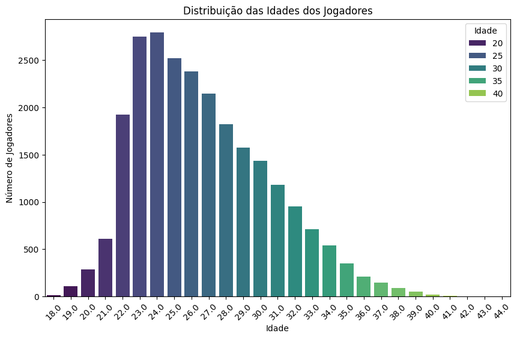

```python
# Gráfico de distribuição das idades dos jogadores
plt.figure(figsize=(10, 6))
sns.countplot(x='Idade', data=dataset, palette='viridis', hue='Idade')
plt.title('Distribuição das Idades dos Jogadores')
plt.xlabel('Idade')
plt.ylabel('Número de Jogadores')
plt.xticks(rotation=45)
plt.show()
```

### Gráfico de Pontos vs. True Shooting Percentage

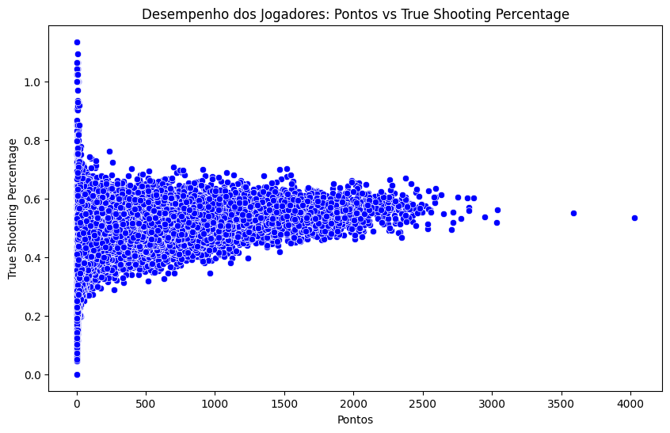

```python
# Gráfico de pontos x precisão de arremessos
plt.figure(figsize=(10, 6))
sns.scatterplot(x='Points', y='TrueShootingPercentage', data=dataset, color='blue')
plt.title('Desempenho dos Jogadores: Pontos vs True Shooting Percentage')
plt.xlabel('Pontos')
plt.ylabel('True Shooting Percentage')
plt.show()
```

### Gráfico de evolução da pontuação ao longo dos anos

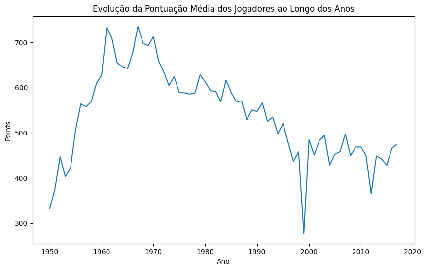

```python
plt.figure(figsize=(10, 6))
sns.lineplot(data=dataset, x='Ano', y='Points', errorbar=None)  # Substituindo ci por errorbar
plt.title("Evolução da Pontuação Média dos Jogadores ao Longo dos Anos")
plt.show()
```

### Histograma das variáveis numéricas

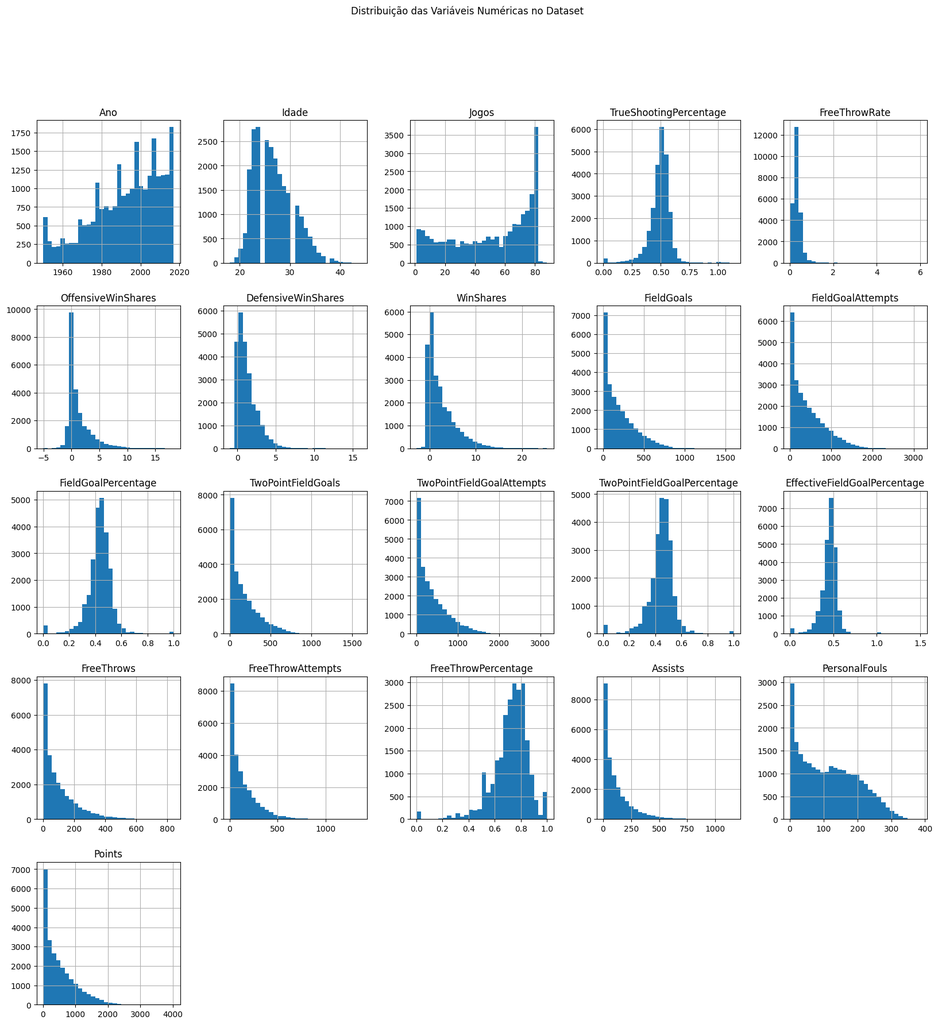

```python
# Histograma das variáveis numéricas
dataset.hist(bins=30, figsize=(20,20))
plt.suptitle("Distribuição das Variáveis Numéricas no Dataset")
plt.show()
```

**Análise:** Os histogramas mostram a distribuição das variáveis numéricas no dataset. Cada gráfico representa uma variável e permite observar como os valores se distribuem, destacando padrões ou concentrações de dados em certos intervalos. Isso ajuda a identificar características importantes, como valores comuns, possíveis assimetrias e variações entre as variáveis.

### Matriz de Correlação entre variáveis

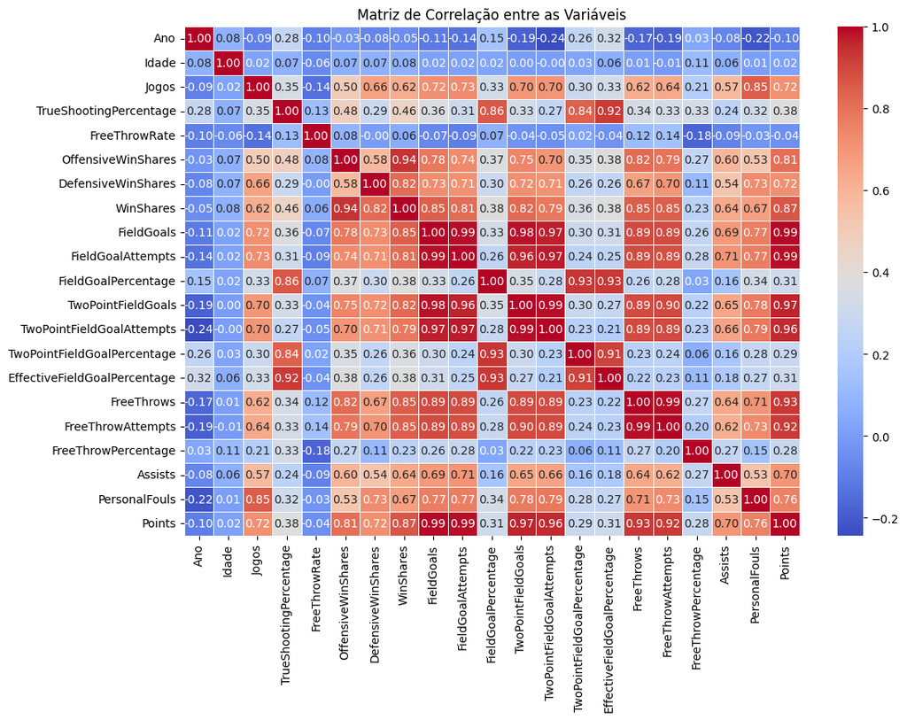

```python
# Selecionar apenas as variáveis numéricas
dataset_numerical = dataset.select_dtypes(include=['float64', 'int64'])

# Remover linhas com valores ausentes (NaN) nas variáveis numéricas
dataset_numerical = dataset_numerical.dropna()

# Calcular a correlação entre as variáveis numéricas
correlation_matrix = dataset_numerical.corr()

# Plotar a matriz de correlação
plt.figure(figsize=(12, 8))
sns.heatmap(correlation_matrix, annot=True, cmap='coolwarm', fmt='.2f', linewidths=0.5)
plt.title('Matriz de Correlação entre as Variáveis')
plt.show()
```

**Análise:** Essa matriz de correlação mostra a relação entre as variáveis numéricas. Cada quadrado indica a força da correlação entre duas variáveis: valores perto de 1 ou -1 significam uma forte relação, enquanto valores próximos de 0 mostram uma relação fraca. Esse gráfico ajuda a identificar as variáveis mais relevantes para análise.

### **3.4 Seleção de Atributos**

A seleção dos atributos foi baseada nas variáveis mais importantes para o desempenho de um jogador de basquete. Atributos como Idade e Pontos ajudam a entender a experiência e a produção do jogador. A eficiência nas jogadas, como o True Shooting Percentage e o Free Throw Rate, também são essenciais, pois refletem a capacidade do jogador em marcar pontos. Outros atributos, como Assistências e Field Goals, mostram a participação do jogador nas jogadas ofensivas. A combinação dessas variáveis ajuda a criar um modelo mais preciso para prever os Pontos do jogador.

```python
# Esses atributos serão usados para treinar o modelo.
atributos_relevantes = [
    'Idade', 'Jogos', 'TrueShootingPercentage', 'FreeThrowRate',
    'OffensiveWinShares', 'DefensiveWinShares', 'FieldGoals', 'FieldGoalAttempts',
    'TwoPointFieldGoals', 'TwoPointFieldGoalAttempts', 'EffectiveFieldGoalPercentage',
    'FreeThrows', 'FreeThrowAttempts', 'Assists', 'PersonalFouls', 'Points'
]

# Criando um novo dataset com apenas esses atributos
dataset_relevante = dataset[atributos_relevantes]

# Visualizando o início do novo dataset
print("Atributos selecionados:")
print(dataset_relevante.head())
```

```
Atributos selecionados:
   Idade  Jogos  TrueShootingPercentage  FreeThrowRate  OffensiveWinShares  \
0   31.0     63                   0.368          0.467                -0.1
1   29.0     49                   0.435          0.387                 1.6
2   25.0     67                   0.394          0.259                 0.9
3   24.0     15                   0.312          0.395                -0.5
4   24.0     13                   0.308          0.378                -0.5

   DefensiveWinShares  FieldGoals  FieldGoalAttempts  TwoPointFieldGoals  \
0                 3.6         144                516                 144
1                 0.6         102                274                 102
2                 2.8         174                499                 174
3                -0.1          22                 86                  22
4                -0.1          21                 82                  21

   TwoPointFieldGoalAttempts  EffectiveFieldGoalPercentage  FreeThrows  \
0                        516                         0.279         170
1                        274                         0.372          75
2                        499                         0.349          90
3                         86                         0.256          19
4                         82                         0.256          17

   FreeThrowAttempts  Assists  PersonalFouls  Points
0                241      176            217     458
1                106      109             99     279
2                129      140            192     438
3                 34       20             29      63
4                 31       20             27      59
```

### Tratamento de Valores Faltantes (NaN)

NaN significa "Not a Number", e ocorre quando há valores ausentes ou indefinidos em um dataset. Para tratar isso, vamos preencher esses valores com a média dos dados para que o modelo não perca informações e funcione de forma eficiente.

```python
# Verificando a presença de valores NaN e a quantidade por coluna
print("Valores ausentes por atributo:")
print(dataset_relevante.isna().sum())

# Preenchendo NaN com a média
dataset_relevante = dataset_relevante.fillna(dataset_relevante.mean())
```

```
Valores ausentes por atributo:
Idade                            8
Jogos                            0
TrueShootingPercentage          86
FreeThrowRate                   99
OffensiveWinShares              39
DefensiveWinShares              39
FieldGoals                       0
FieldGoalAttempts                0
TwoPointFieldGoals               0
TwoPointFieldGoalAttempts        0
EffectiveFieldGoalPercentage    99
FreeThrows                       0
FreeThrowAttempts                0
Assists                          0
PersonalFouls                    0
Points                           0
dtype: int64
```

### Definição da Variável-Alvo (y)

O atributo alvo escolhido foi 'Points', pois queremos prever quantos pontos um jogador fará com base nas suas outras estatísticas. 'Points' é o resultado que o modelo vai tentar estimar a partir das variáveis de entrada.

```python
# Variável alvo (y)
X = dataset_relevante.drop('Points', axis=1)
y = dataset_relevante['Points']
```

## **4. Divisão dos dados em treino e teste**

Dividimos os dados em dois conjuntos: treino e teste. O conjunto de treino é usado para ensinar o modelo, enquanto o conjunto de teste é utilizado para avaliar a precisão do modelo em dados que ele nunca viu antes, garantindo que ele seja capaz de generalizar bem para novos dados.

```python
# Dividindo o conjunto de dados em treino e teste para avaliar a performance do modelo em dados não vistos
X_train, X_test, y_train, y_test = train_test_split(X, y, test_size=0.2, random_state=42)

# Treinando o modelo de Regressão Random Forest com os dados de treino
model = RandomForestRegressor()
model.fit(X_train, y_train)
```

```
RandomForestRegressor()
```

### Importância dos Atributos

Calculando a importância dos atributos para entender quais variáveis mais contribuem para a previsão do modelo. Isso é útil porque ajuda a identificar os fatores mais relevantes e podemos focar neles para melhorar o desempenho do modelo.

[figure not shown]

```python
# Calculando a importância dos atributos
importances = model.feature_importances_
indices = np.argsort(importances)

# Verificar se selected_features está corretamente definido
if 'selected_features' not in locals():
    selected_features = X.columns  # Use as colunas de X se não tiver feito a seleção

# Plotando a importância dos atributos
plt.figure(figsize=(10, 6))
plt.title('Importância dos Atributos')
plt.barh(range(len(indices)), importances[indices], align='center')
plt.yticks(range(len(indices)), [selected_features[i] for i in indices])
plt.xlabel('Importância Relativa')
plt.show()
```

### Avaliação do Modelo

Avaliação do modelo com as métricas MSE (Erro Quadrático Médio) e R² (Coeficiente de Determinação). O MSE mede o erro médio das previsões; quanto menor, melhor o modelo. O R² indica a porcentagem da variação dos dados explicada pelo modelo; quanto mais próximo de 1, melhor.

```python
# Avaliação no conjunto de teste
y_pred = model.predict(X_test)
mse = mean_squared_error(y_test, y_pred)
r2 = r2_score(y_test, y_pred)

print("Mean Squared Error (MSE):", mse)
print("R-squared (R2):", r2)
```

```
Mean Squared Error (MSE): 196.08606804060915
R-squared (R2): 0.9992078771153098
```

## **5. Definição do problema**

Estamos lidando com um problema de **regressão**, onde o objetivo é prever um valor contínuo (como os pontos de um jogador) com base em variáveis como Idade e Jogos. Isso é característico de modelos de regressão, que são usados para prever números e não categorias.

## **6. Treinando um algoritmo de Aprendizagem Supervisionada**

Como já vimos o RandomForestRegressor em aula, vamos utilizá-lo para treinar a máquina com os dados de treino. O Random Forest é um algoritmo de aprendizado supervisionado que combina várias árvores de decisão para melhorar a precisão das previsões.

```python
# Criando e treinando o modelo RandomForest
rf = RandomForestRegressor(n_estimators=100, random_state=42)
rf.fit(X_train, y_train)

# Realizando previsões na base de teste
y_pred = rf.predict(X_test)

# Avaliação do modelo
mse = mean_squared_error(y_test, y_pred)
r2 = r2_score(y_test, y_pred)

print(f'Mean Squared Error (MSE): {mse}')
print(f'R²: {r2}')
```

```
Mean Squared Error (MSE): 199.15986318781725
R²: 0.9991954599991767
```

## **7. Avaliando o Modelo**

### Gráfico de erro residual

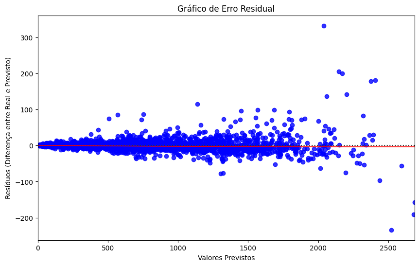

```python
# Calculando os resíduos
residuos = y_test - y_pred

# Plotando o gráfico de erro residual
plt.figure(figsize=(10,6))
sns.residplot(x=y_pred, y=residuos, lowess=True, color="blue", line_kws={"color": "red", "lw": 1})
plt.title("Gráfico de Erro Residual")
plt.xlabel("Valores Previstos")
plt.ylabel("Resíduos (Diferença entre Real e Previsto)")
plt.show()
```

### **Conclusão**

Esta Atividade Somativa foi uma excelente oportunidade para aplicar técnicas de machine learning e avaliar o desempenho de modelos em problemas práticos. Utilizei o modelo RandomForest, que obteve resultados muito positivos, com um R² de 0.9992, indicando alta precisão nas previsões dos pontos dos jogadores.

Ao longo da atividade, busquei melhorar minha compreensão do dataset e refinar o código, consultando o ChatGPT para esclarecer dúvidas e correção de códigos. As revisões feitas nas semanas 1, 2 e 3 foram fundamentais para o sucesso da atividade, assim como a revisão da semana 4, que consolidou meu entendimento sobre as ferramentas utilizadas.

**Próximos Passos:**

- **Refinamento do modelo:** A performance do modelo pode ser ainda melhorada para otimizar o desempenho.
- **Exploração de novos atributos:** Podemos expandir o conjunto de dados incluindo mais variáveis que podem ter impacto no desempenho dos jogadores, como "tempo de jogo", "lesões", etc.
- **Análise de outros algoritmos:** Embora o Random Forest tenha apresentado bons resultados, é interessante comparar com outros modelos de regressão, como XGBoost, para verificar se algum modelo alternativo pode superar os resultados obtidos.

Estou satisfeita com o aprendizado adquirido e animada para aplicar essas técnicas em outros projetos e desafios reais.